# Microbial Association Network with NetCoMi

11-Jun-2025

**Organisation:** Data Science Platform  
**Responsibles:** Alberto Pallejà Caro (apca@biosustain.dtu.dk)  
Sebastian Ayala Ruano (asaru@dtu.dk)  
Juliana Assis (jasge@dtu.dk)

This markdown is to create microbial association networks (MANs) based on the abundance data using the the NetCoMi package.

# 1 Work environment setup

## 1.1 Import R Packages

```r
library(NetCoMi)
library(ggplot2)
library(tidyr)
```

## 1.2 Load data

```r
# Abundance table
abundance <- readRDS(file = "../data/MetaphlanAbundance_Species.rds")
rownames(abundance) <- gsub("_SRR_db1.metaphlan", "", rownames(abundance))
dim(abundance)
```

```
## [1]  18 293
```

```r
# Taxonomical annotation
annotation <- readRDS(file = "../data/MetaphlanAnnotations_Species.rds")
dim(annotation)
```

```
## [1] 293   7
```

```r
# Metadata
metadata <- read.table(file = "../data/metadata.tsv",
                       header = TRUE, sep = "\t",
                       quote = "",
                       row.names = NULL)
rownames(metadata) <- metadata$Sample
dim(metadata)
```

```
## [1] 18 21
```

```r
# Take only samples with sequencing and metadata information
abundance <- abundance[rownames(abundance) %in% rownames(metadata),]
dim(abundance)
```

```
## [1]  18 293
```

```r
# Replace the column names of the abundance table with the species names
colnames(abundance) <- annotation$species[match(colnames(abundance), rownames(annotation))]
```

## 1.3 Create a directory to store the results

```r
results_dir <- "results/report/05_Microbial-association-networks"

dir.create(results_dir, recursive = TRUE, showWarnings = FALSE)
```

# 2 Network construction

We create a Microbial association network (MAN) with the [Correlation inference for Compositional data through Lasso (CCLasso)](https://netcomi.de/reference/cclasso) method. **CCLasso** estimates positive definite Pearson correlations from log-ratio variances using a **latent variable model** based on least squares with an L1 penalty. [Aitchison](https://doi.org/10.1111/j.2517-6161.1982.tb01195.x) introduced log-ratios as a basis for analyzing compositional data, as these values are independent of the total sum of counts. Consequently, CCLasso addresses the compositional nature of metagenomics data.

The [`netConstruct()`](https://netcomi.de/reference/netconstruct) function is used to build the network. To make the calculations feasible, we filter the taxa to the 50 most abundant species using the `filtTax` and `filtTaxPar` parameters.

Normalization is performed internally as part of the CCLasso method, so we set `normMethod` to `none`. To handle zeros in the data, we applied the `pseudoZO` method, which adds a pseudo count of 1 to zero values.

The `signed` method was aplied for transforming associationss into dissimilarities, so that **strongly negatively associated taxa** have a high dissimilarity and, in turn, a low similarity, which corresponds to **edge weights** in the network plot.

A threshold of `0.5` is applied as **sparsification method**, meaning that only species with a correlation greater than or equal to 0.5 will be included in the network.

The **verbose** argument is set to `3` so that all messages generated by `netConstruct()` as well as messages of external functions are printed. Finally, we set a **seed** for reproducibility.

```r
net_cclasso <- netConstruct(abundance,
                           measure = "cclasso",
                           filtTax = "highestFreq",
                           filtTaxPar = list(highestFreq = 50),
                           normMethod = "none",
                           zeroMethod = "pseudoZO",
                           dissFunc = "signed",
                           sparsMethod = "threshold",
                           thresh = 0.5,
                           verbose = 3,
                           seed = 2236)
```

```
## Checking input arguments ... Done.
## Data filtering ...
## 243 taxa removed.
## 50 taxa and 18 samples remaining.
##
## Zero treatment:
## Zero counts replaced by 1
##
## Normalization:
## Counts normalized by total sum scaling.
##
## Calculate 'cclasso' associations ...
## current loss diff.: -Inf (breaks if >= Inf)current loss diff.: -2.182278 (breaks if >= 0.001261)current loss diff.: -2.277094 (breaks if >= 0.001259)current loss diff.: -2.296702 (breaks if >= 0.001256)current loss diff.: -2.229085 (breaks if >= 0.001254)current loss diff.: -2.218892 (breaks if >…
## Done.
##
## Sparsify associations via 'threshold' ... Done.
```

Now, we can check and save the **edge list** of the network. It contains the estimated associations, dissmiliarities, and similarities (`adj` column) for each pair of species.

```r
head(net_cclasso$edgelist1)
```

|  | v1 | v2 | asso | diss | adja |
| --- | --- | --- | --- | --- | --- |
| 1 | Halomicroarcula rubra | Haloplanus rubicundus | 0.6075220 | 0.4429887 | 0.5570113 |
| 2 | Halomicroarcula rubra | Halorubrum depositum | 0.7158338 | 0.3769391 | 0.6230609 |
| 3 | Halomicroarcula rubra | Halolamina sediminis | 0.7503077 | 0.3533357 | 0.6466643 |
| 4 | Halomicroarcula rubra | Halorientalis marina | 0.5758867 | 0.4604961 | 0.5395039 |
| 5 | Halomicroarcula rubra | Haloplanus aerogenes | 0.5720215 | 0.4625897 | 0.5374103 |
| 6 | Halomicroarcula rubra | Natronomonas sp_ZY43 | 0.6434142 | 0.4222474 | 0.5777526 |

```r
write.table(net_cclasso$edgelist1,
            file = file.path(results_dir, "1_cclasso_network_edgelist.csv"),
            sep = ",", quote = FALSE, row.names = FALSE)
```

We can also use the`plotHeat` function to plot the estimated associations.

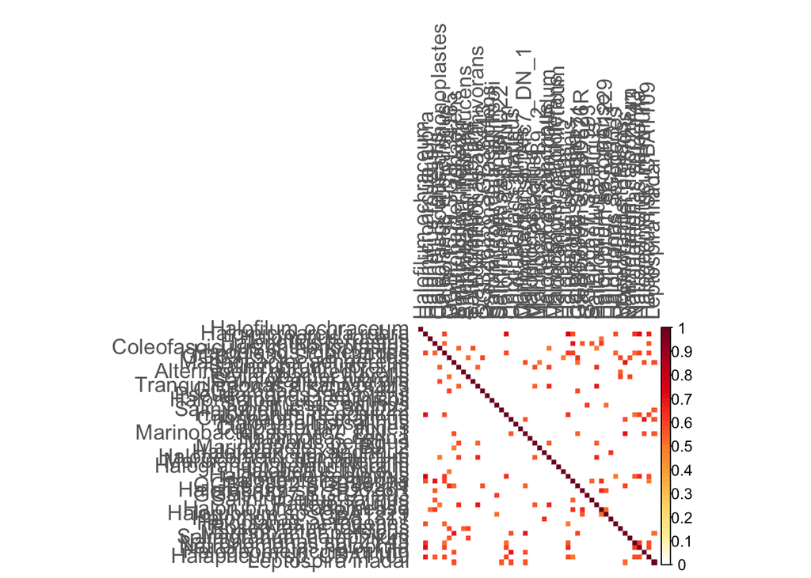

```r
# Generate the plot
heatmap <- plotHeat(net_cclasso$assoMat1, textUpp = "none", textLow = "none")
```

```r
# Open and close PNG device
png(file.path(results_dir, "2_cclasso_network_association_heatmap.png"), width = 2000, height = 1800, res = 150)
dev.off()
```

# 3 Network analysis

The [`netAnalyze()`](https://netcomi.de/reference/netanalyze) function is used for analyzing the MAN.

Here, **centrLCC** is set to `FALSE`, so the centralities are calculated for all nodes in the network, not only for those in the **largest connected component (LCC)**. **weightDeg** and **normDeg** are set to `FALSE`, so that the degree of a node is simply defined as the number of connections it has to other nodes.

**Hubs** are defined here as nodes with a degree above the 90% quantile of the empirical degree distribution, which is specified by the **hubPar** and **hubQuant** arguments.

Clusters are identified using the **greedy modularity optimization** algorithm ([`cluster_fast_greedy`](https://r.igraph.org/reference/cluster_fast_greedy.html)). This algorithm optimize the modularity of networks by iteratively grouping nodes into communities, aiming to maximize the density of intra-community edges compared to inter-community edges

```r
props_cclasso <- netAnalyze(net_cclasso,
                            # Centrality
                            centrLCC = FALSE,
                            weightDeg = FALSE,
                            normDeg = FALSE,

                            # Hubs
                            hubPar = "degree",
                            hubQuant = 0.9,

                            # Clustering
                            clustMethod = "cluster_fast_greedy"
                    )
```

[figure not shown]

```r
# Print the summary of the network analysis
summary(props_cclasso, numbNodes = 5L)
```

`````````````````````````````````
##
## Component sizes
## ```````````````
## size: 17 16 7 2 1
##    #:  1  1 1 1 8
## ______________________________
## Global network properties
## `````````````````````````
## Largest connected component (LCC):
##
## Relative LCC size          0.34000
## Clustering coefficient     0.66538
## Modularity                 0.33403
## Positive edge percentage 100.00000
## Edge density               0.30147
## Natural connectivity       0.15871
## Vertex connectivity        1.00000
## Edge connectivity          1.00000
## Average dissimilarity*     0.83397
## Average path length**      1.36608
##
## Whole network:
##
## Number of components      12.00000
## Clustering coefficient     0.66747
## Modularity                 0.69582
## Positive edge percentage 100.00000
## Edge density               0.06776
## Natural connectivity       0.03990
## -----
## *: Dissimilarity = 1 - edge weight
## **: Path length = Units with average dissimilarity
##
## ______________________________
## Clusters
## - In the whole network
## - Algorithm: cluster_fast_greedy
## ````````````````````````````````
##
## name: 0 1 2 3 4 5 6
`````````````````````````````````

[output cut: 33 more lines]

```
## Closeness centrality (normalized):
##
## Halomicroarcula rubra 0.51384
## Haloplanus rubicundus 0.49825
## Halapricum sp_CBA1109 0.47754
## Halorientalis marina  0.46796
## Halonotius terrestris 0.45794
##
## Eigenvector centrality (normalized):
##
## Halomicroarcula rubra     0.40476
## Haloplanus rubicundus     0.39605
## Marinobacter sp_Arc7_DN_1 0.38095
## Halapricum sp_CBA1109     0.37681
## Halolamina sediminis      0.36244
```

# 4 Network visualization

Finally, we can visualize the network using the [`plot()`](https://netcomi.de/reference/plot) function.

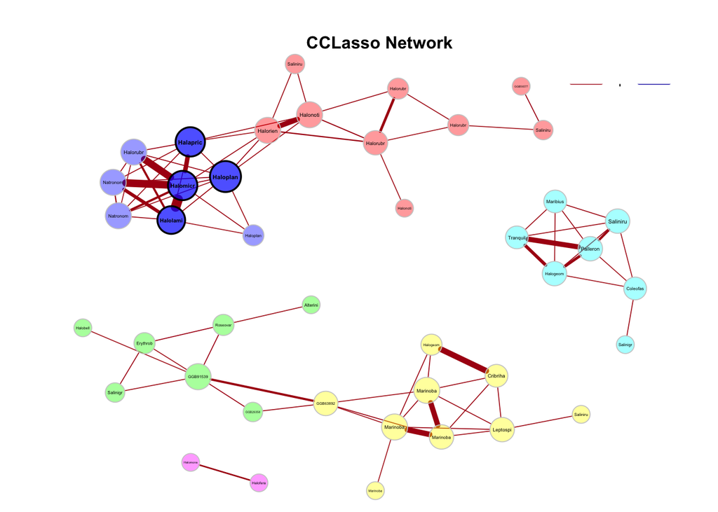

```r
# Generate the plot
net_viz <- plot(props_cclasso,
     # Network
     layout = "spring",
     repulsion = 0.9,
     title1 = "CCLasso Network",
     showTitle = TRUE,
     rmSingles = TRUE,
     cexTitle = 1,

     # Nodes
     nodeColor = "cluster",
     nodeSize = "degree",
     cexNodes = 2.7,
     nodeSizeSpread = 2,
     shortenLabels = "simple",
     labelLength = 8L,

     # Edges
     posCol = "#ac1214", # red
     negCol ="#0d1fad", # blue
)

legend(0.7, 1.1, title = "Estimated associations:", legend = c("+","-"),
        col = c("#ac1214","#0d1fad"), inset = 0.02, cex = 0.8, lty = 1, lwd = 3.5,
        bty = "n", horiz = TRUE, y.intersp = 0.7)
```

```r
# Open and close PNG device
png(file.path(results_dir, "3_cclasso_network.png"), width = 2500, height = 2300, res = 150)
dev.off()
```

# 5 Further information

The [Network learning & analysis](https://microbiome.github.io/OMA/docs/devel/pages/network_learning) chapter from the [Orchestrating Microbiome Analysis Book](https://microbiome.github.io/OMA/docs/devel/) provides more details about all the steps and consideration to take when creating and analyzing microbial association networks (MANs).